# The Space Environment

#### V. Hunter Adams (vha3), MAE 4160/5160, Spring 2020

```python
from IPython.display import Latex
from IPython.display import Image
from IPython.core.display import HTML
```

###### “The most terrifying fact about the universe is not that it is hostile but that it is indifferent, but if we can come to terms with this indifference, then our existence as a species can have genuine meaning. However vast the darkness, we must supply our own light." - Stanley Kubrick

Space is a difficult place to be. Today's lecture is a survey of the environment in which spacecraft operate, and a discussion of how this environment affects spacecraft and drives their requirements.

This lecture is placed at this point in the course (as opposed to being placed at the very beginning of the course) because the space environment particularly affects the avionics subsystem, which is the subject of the next class.

## Other reading

1. SMAD 7

## Atmosphere

### Drag

The atmosphere does not have a defined edge. The transition from atmosphere to space is a gradual one, and atmospheric particles can be found (in decreasing density) well into Low Earth Orbit and beyond. This rarified atmosphere cannot be ignored. It affects spacecraft in significant ways. Mostly, via drag. Recall the drag model from 4060, and which we went over in a previous lecture:

\begin{align} D &= \frac{1}{2} \rho V^2 \frac{C_D A}{m} \end{align}

$V$ is the spacecraft velocity, $C_D$ is the drag coefficient (which depends on the shape of the spacecraft), $A$ is the effective surface area of the spacecraft, and $\rho$ is the atmospheric density. We care about atmospheric density because it appears in this equation, which means that it contributes to an external force on the spacecraft, which affects the spacecraft's trajectory.

### Density

The temperature profile of our atmosphere does not monotonically decrease with altitude. It increases and decreases a number of times as one moves upward. These temperature deviations provide a useful metric for dividing the atmosphere into layers, as shown below.

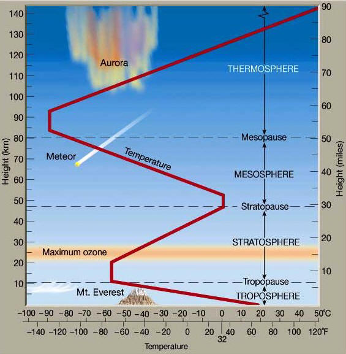

```python
Image("layer.jpg", width=400)
```

The thermosphere extends to about 700 km altitude, beyond which one enters the exosphere. Though the height of the thermopause (the border between thermosphere and exosphere) varies considerably with solar activity. Most spacecraft exist in the thermosphere.

Relatively simple models for atmospheric density work pretty well up to ~20 km. Isothermal models (assume that the atmosphere is an ideal gas which is in hydrostatic equilibrium) work up to about 10 km. This model, however, assumes that temperature is constant, which is a bad assumption.

A slightly more sophisticated adiabatic model incorporates temperature deviation and assumes no transfer of heat. This model, in combination with the hydrostatic equilibrium equations, will get you a good approximation up to about 20 km. Beyond that, things get complicated. The air is no longer well mixed, so each species must be modeled separately. Furthermore, the atmosphere has time dependence. So, in practice, folks use lookup tables based on much more complicated models which include more of these degrees of freedom. There are a number of such models, NASA recommends MSISE.

The **density** in this region, which is what we care about for drag calculations, is driven principally by the Sun. Heating, and subsequent density changes, occur when photons from the Sun are absorbed by the particles in the thermosphere. This is called *photoabsorption*. Absorption of a photon results in either the ionization of the molecule (an electron is stripped away, and runs off with a lot of kinetic energy) or photodissociation (a molecule gets broken apart, and the consituent pieces run off with the energy from the photon). Clearly, these processes depend on the amount of irradiance coming from the Sun, which varies. It can vary with flare (hours), solar rotation (27 days), active region evolution (3-6 months), and solar cycle (10-12 years). So, the density of the thermosphere is affected on the same timescales.

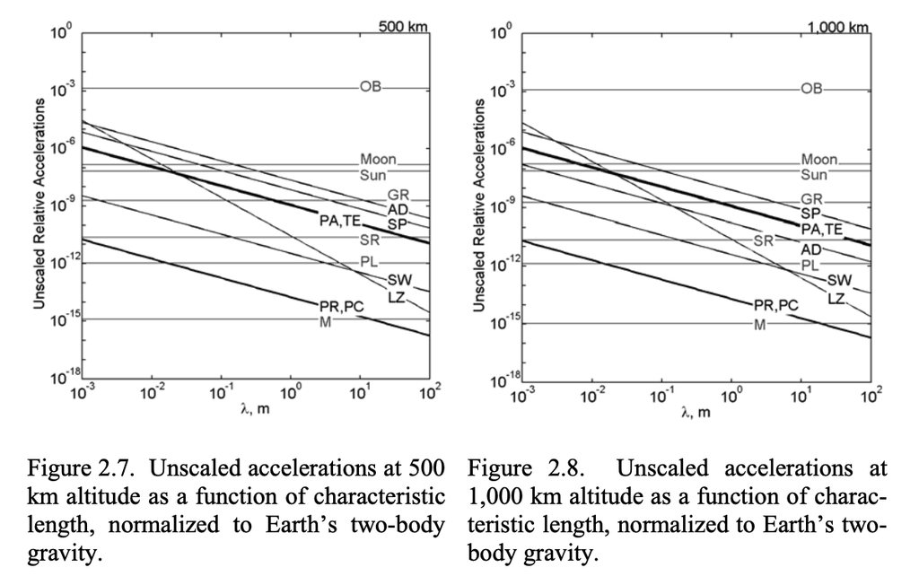

```python
Image("acc.png", width=600)
```

As shown in the plots above, from Justin Atchison's thesis, atmospheric drag is strong up to 500 km, and largely negligible after that. A cubesat in 400 km orbit has a lifetime of 1-9 months, while a cubesat at 600 km has a lifetime of over 25 years. These lifetimes decrease as the drag coefficient of the spacecraft increase. For chipsats, these lifetimes are much lower, on the order of days at 400 km orbit.

This solar activity also facilitates the creation of **atomic oxygen**.

### Atomic oxygen

At 200-600 km, atomic oxygen is the predominant atmospheric constituent. This is formed when far UV radiation dissociated O2. Above 110 km, the constituents of the atmosphere distribute themselves based on how affected they are by gravity. Heavier elements appear in decreasing abundance faster than lighter elements as one climbs in altitude. Atomic oxygen is lighter than nitrogen and oxygen and thus, above 200 km, it is the dominant element.

This requires consideration, since atomic oxygen reacts with organic films, advanced composites, and metallized surfaces. Spacecraft materials must be chosen with the understanding that the spacecraft will be operating in an atomic oxygen environment. In some cases, it may even be prudent to phase one's mission with the solar cycle so that the spacecraft operates during an atomic oxygen minimum.

One often protects a spacecraft by coating it with a material which is "immune" to O. This could be silicon dioxide or aluminum.

### Ionosphere

The thermosphere and ionosphere are coupled. The ionosphere is formed by solar photons stripping electrons from the neutral particles which compose the thermosphere. The consequence is a plasma, a region of charged particles. These charged particles are only formed when struck by solar radiation, so there is a diurnal cycle to the ionosphere. When the Sun goes down, electrons reattach to ions, creating neutrals, and collapsing the ionosphere.

These charged particles *differentially charge the spacecraft, on both its exterior and interior.* Differential charges significant enough to exceed breakdown electric fields can occur, causing electrostatic discharges which can be large enough to disrupt electronics. In less extreme cases, this charging can alter the electrical potential of the spacecraft as compared to the surrounding space, which can affect instrumentation.

*There's no electrical ground in space.*

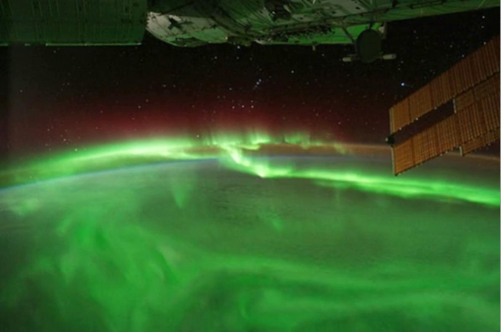

```python
Image("aurora.jpg", width=600)
```

### West Ford needles

Many of you are likely aware that the ionosphere is useful for long-distance radio communications. The ionized gasses within the ionosphere will reflect radio waves back toward the Earth, enabling communication to receivers over the horizon. This communication method is variable and unreliable, however, relying on things such as time of day, season, weather, and the sun cycle.

During the Cold War, international communications from the United States were sent through undersea cables or bounced off the ionosphere. The US was worried that the Soviet Union would cut their undersea cables, forcing them to rely on the unpredictable and unreliable ionosphere. So, *they attempted to create their own version of the ionosphere*.

From Wikipedia: To mitigate the potential threat, a ring of 480,000,000 copper dipole antennas (needles which were 1.78 centimetres long and 25.4 micrometres in diameter) were placed in orbit to facilitate global radio communication. The length was chosen because it was half the wavelength of the 8 GHz signal used in the study. The dipoles collectively provided passive support to Project Westford's parabolic dish (located in the town of Westford) to communicate with distant sites. In 1958, at MIT’s Lincoln Lab, Walter E. Morrow started Project Needles.

They placed these needles in Medium Earth Orbit (3500 - 3800 km). A lot of people got upset.

Many of the needles deorbited in ~3 years, but there are still clumps up there. 40, as of May 2019. This led ultimately to the 1967 Outer Space Treaty, which outlined a few rules for everyone to follow in space.

[figure not shown]

```python
Image("westford.jpg", width=600)
```

## Vacuum

Many materials contain trapped gasses which are held in place by atmospheric pressure. These materials include adhesives, insulators, thermal coatings, electrical shielding, etc. When atmospheric pressure is removed by transporting these materials to a vacuum environment, these trapped gasses are released. This process is further facilitated by the decreased sublimation and evaporation points caused by the vacuum.

The outgassed material has a tendency to condense onto cooler surfaces, which often include optical elements (i.e. camera lenses), radiators, and solar cells. The consequence can be decreased performance of all of these materials. Some materials outgas more than others. To outgassing, NASA selects materials with favorable outgassing properties (see https://outgassing.nasa.gov) and they "bake out" components. That is, they place components in thermal vacuum chambers to facilitate the worst of the outgassing process on Earth rather than on orbit.

The difference in pressure between here and space is approximately the same as that between here and 33 ft. under the ocean. Open water SCUBA certification allows you to go down to 60 ft. The atmospheric pressure on the surface of Venus, by the way, is the same as that at 3000 ft. underwater. Human launches from the surface would have to take the bends into consideration.

## Magnetic field

The Earth's magnetic field is created by dynamo feedback effect. A rotating, conducting, convecting inner core can maintain a magnetic field over astronomical timescales. This magnetic field is approximately dipolar, but with many higher-order perturbations. In practice, just like for atmospheric density, folks use lookup tables based on sophisticated models that are informed by distributed measurements. These include the World Magnetic Model (WMM) and the International Geomagnetic Reference Field (IGRF). The Earth's magnetic field is responsible for the **magnetosphere**. The magnetosphere is the region around the Earth in which ions are controlled by the Earth's magnetic field.

The magnetic field is subject to perturbation by the plasma of the solar wind. These interactions cause the magnetic field on the night-side of the Earth to stretch into an elongated structure called the *magnetotail.* This tail extends over 1000 Earth radii. The trajectory of charged particles is affected by the magnetic field, and they are redirected, bounced, and drifted. This is how the magnetic field protects us from much of the energy coming from the Sun.

Through interaction with the magnetic field, some of the solar wind's kinetic energy is converted into magnetic energy stored in the magnetotail. *Geomagnetic storms* are large disturbances in the geomagnetic field caused by interactions with these solar winds (often in connection to an event which leads to high flux, like a coronal mass ejection). These storms lead to an increase in energetic ions (charged particles) in the region just inside geosynchronous orbit. The consequence can be increased charge on your spacecraft.

Discharge risk can be mitigated by careful selection of materials and with conductive coatings which allow charge to distribute itself across the spacecraft.

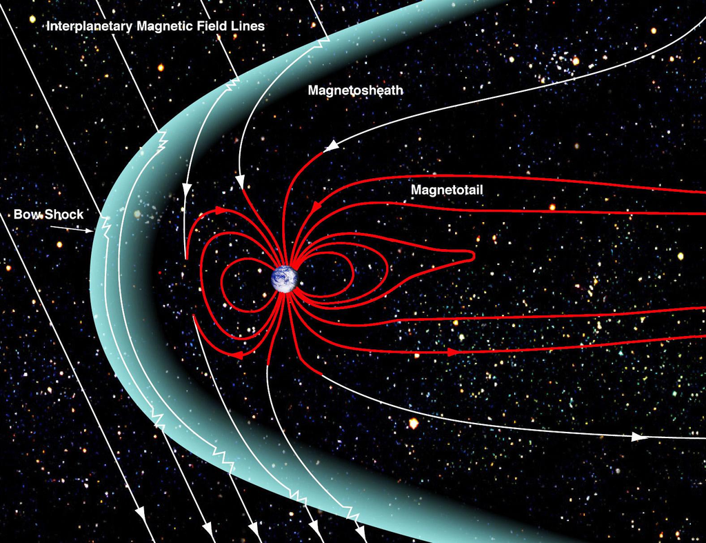

```python
Image("magneto.jpg", width=600)
```

## The Sun

### Electromagnetic radiation

Electromagnetic radiation is carried by waves and massless photons. Electromagnetic radiation is described by its frequency/wavelength, its energy, and its momentum. The equations that relate these quantities are given below.

\begin{align} f &= \frac{c}{\lambda}\\ E &= hf = \frac{hc}{\lambda}\\ p &= \frac{E}{c} = \frac{h}{\lambda} \end{align}

### Solar radiation and solar cycles

Energy is tranferred from the Sun to Earth via electromagnetic radiaon (photons), charged particles (ions/electrons), and magnetic, electric, and gravitational field. Sometimes, events at the Sun can radically increase the amount of energy that gets tranferred to the Earth per unit time. These events include solar flares (huge bursts of electromagnetic radiation in all wavelengths, but mostly in x-ray and UV) and coronal mass ejections (extremely high-speed ejections of particles including ions and electrons). These particles take approximately 3 days to get to Earth, and when they arrive they interact with the Earth's magnetic field. This causes geomagnetic storms which can increase the prevalence of charged particles in the Earth's magnetosphere, consequently charging-up spacecraft. This can also affect the temperature of the thermosphere, and thus its density, leading to variations in drag acting on the spacecraft.

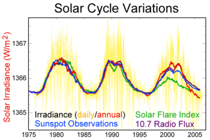

```python
Image("cycle.png", width=600)
```

## Galactic cosmic rays

Galactic cosmic rays are radiation that orginated *outside* the solar system (from supernovie, black holes, etc.). These are far more energetic than solar cosmic rays from coronal mass ejections, having energies in the GeV-PeV range. These are protons or heavier ions traveling at relativistic speeds. If they strike a sensitive piece of electronic equipment (a transistor, for example), they can destroy it. This is known as a *single event burnout*. In less severe cases, the GCR may simply cause a bitflip, which neither damages the part nor interferes with subsequent operation (*single-event upset*), or it may cause a *single event latchup* where the part hangs and draws excess current, requiring a reboot to return to normal operations.

These particles are arriving all the time (lookup bubble tanks), but their frequency is at a maximum when the solar cycle is at a minimum. In every square meter, 10 GeV particles are arriving per millisec. 1 TeV particle arrives every second, and one PeV particle arrives every year.

This cause single-event upsets from which it can be impossible to recover, and which can have bizarre effects. Listen to the "bit flip" episode of Radiolab. Risk can be mitigated by using radiation-hardened electronics.

[figure not shown]

Cloud chamber showing cosmic rays.

#### KickSat cautionary tale

The first KickSat mission fell victim to radiation.

KickSat launched in 2014. It was carried to ISS by a cargo resupply mission, and subsequently deployed. Whenever a spacecraft is deployed from another spacecraft, there's a particular amount of time that the deployed spacecraft may not use any actuators or radios. The folks in charge of the other spacecraft want to make certain that no action is taken which could pose any risk. This is particularly true for ISS.

And it's particularly, particularly true for KickSat, which was supposed to deploy over 100 chipsats. KickSat had to wait an agreed-to amount of time before deploying any chipsats, so that it would be decidedly below station and would not pose any debris risk. I believe the delay was 2 weeks.

In order to measure time, an onboard timer was used. A radiation event occurred near the chipsat deployment date, triggering a timer reset. This reset the time until chipsat deployment for another two weeks. By the time the counter counted all the way down, KickSat had reentered the atmosphere and all chipsats were lost.

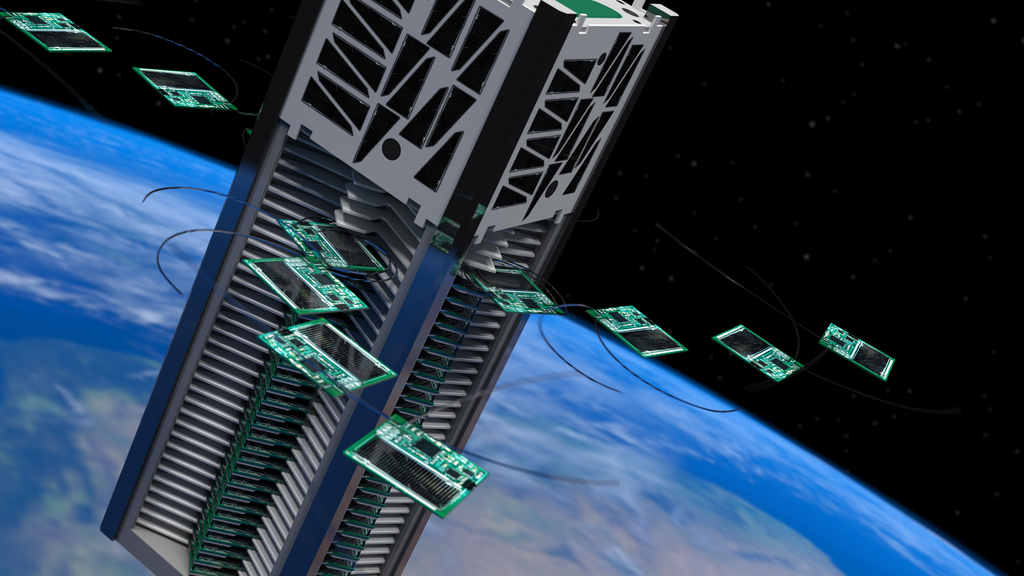

```python
Image("kick.jpg", width=600)
```

#### Optic nerves of astronauts

Known as "Cosmic ray visual phenomena," there are many cases of astronauts reporting "spots," "stars," "streaks," and "blobs" in space, even when their eyes are closed. These are visual artifacts of cosmic rays interacting with some aspect of the visual system. The precise mechanism is unknown. Cosmic rays may be causing Cherenkov radiation as they pass through the vitrius humor of the eye, resulting in a flash. They may be interacting directly with the optic nerve or the visual center of the brain, and/or retinal receptor stimulation.

## Van Allen belts

There are two toroidal regions around the Earth with particularly high concentrations of high-energy (>30 keV) electrons and ions. The inner belt is located at ~1000-6000 km altitude, and the outer belt is at ~13000-60000 km. Most LEO satellites exists below the first ring. However, satellites at GEO are on the edge of the outer ring and must therefore deal with higher doses of radiation.

They do so with shielding. Engineers estimate the amount of shielding required by estimating the total amount of radiation to which the spacecraft will be exposed during its operational lifetime. There are various units with which one can quantify radiation dosages. One is the Rad. This is the dose causing 100 ergs of energy to be absorbed by one gram of matter. This has been replaced by the SI unit of *grays*, which is Joules per unit kg.

You may also see radiation measured in Rems (Roentgen Equivalent Man), which is a unit of equivalent radiation dose. One rem carries with it a 0.05% chance of eventually developing cancer. Doses greater than 100 rem received over a short time period are likely to cause acute radiation syndrome, possible leading to death within weeks if left untreated.

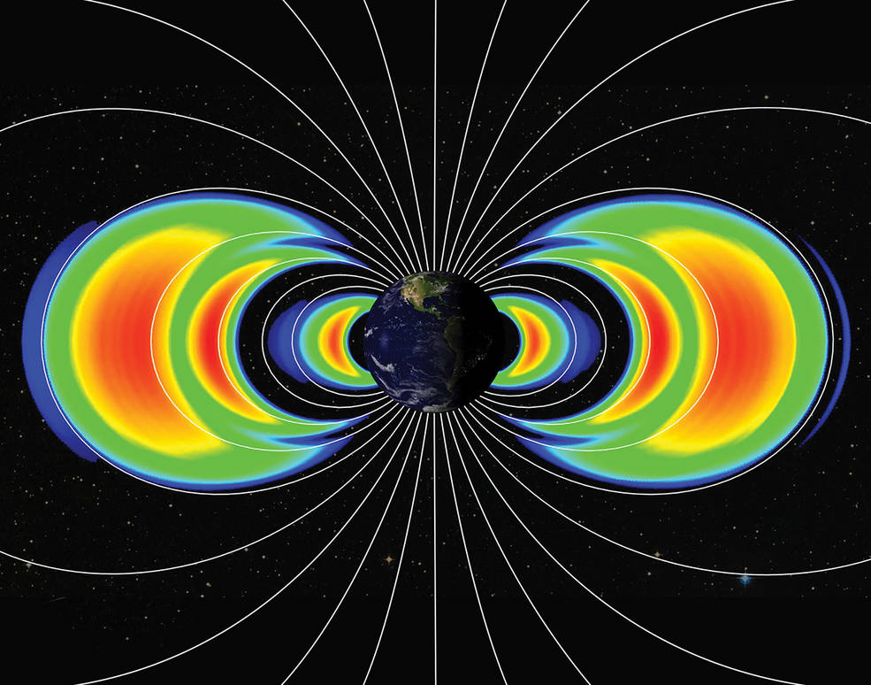

```python
Image("vanallen.jpg", width=600)
```

#### The Demon Core

"Tickling the tail of a sleeping dragon." - Richard Feynman. Google this if you're interested in extreme cases of human radiation exposure, and hard lessons learned.

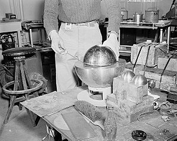

```python
Image("demon.jpg", width=600)
```

## Microgravity

In microgravity (~$10^{-6}$ g), bubbles don't rise, objects don't fall, particles don't settle in a solution, and there is no convection. This presents a number of challenges (mostly to astronauts) and opportunities.

After an extended time in microgravity, an astronaut will experience bone and muscle loss, cardiovascular problems, and a compromised immune system. However, the lack of gravity also offers the opportunity for the formation of large crystals (perhaps creating novel materials opportunities). Containerless processing and working in the vacuum creates the opportunity too for extremely pure chemicals, perhaps for use in either pharmaceuticals or manufacturing.

## Orbital debris

Orbital debris is any non-operational object in orbit, which includes both natural and manmade objects. The **average** relative velocity in LEO between orbiting objects is 9 to 10 km/sec, with maximum values that exceed 14 km/sec. At these velocities, even small objects carry a tremendous amount of energy. As SMAD states, a 1 kg object impacting at 10 km/sec has the equivalent energy of 25 sticks of dynamite.

There is a range of possible effects on a spacecraft, due to the range of sizes of orbital debris. Many impacts will not affect performance of the spacecraft at all, and are only apparent if the spacecraft is returned to the Earth for study. Hubble, for example, is peppered with small impacts. Over time, this can lead to surface degradation.

Collisions have happened. In 2010, there were over 203 satellite fragmentations and collisions. Among the more catastrophic was a collision between the COSMOS 2251 and IRIDIUM 33 spacecraft, which resulted in total destruction of each. All objects above 10 cm are visible from Earth and are currently being trakced and catalogued. There are, however, *many* objects smaller than this that are currently in orbit.

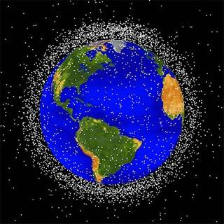

```python
Image("debris.jpg", width=300)
```